# R for Phylogenies: Introduction

For that, we can turn back to the other plant-specific stored tree in Phylomatic, known as “zanne2014”

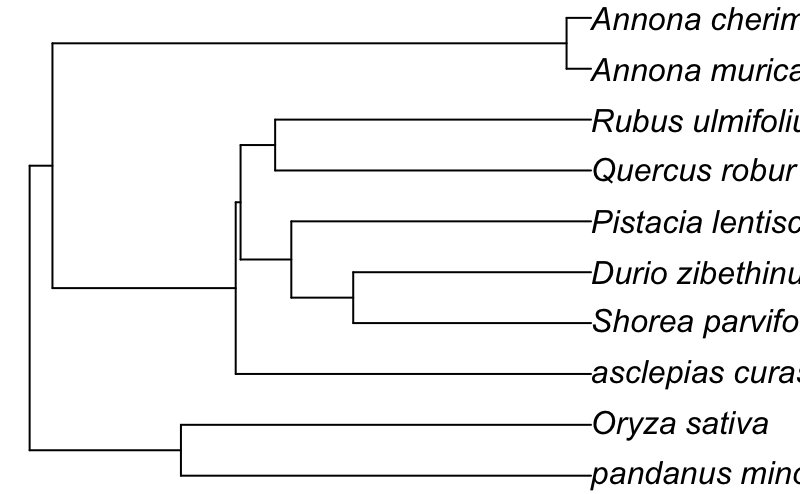

```r
tree_phylomatic <- phylomatic(taxa = spp1, storedtree ="zanne2014", get = 'POST')
plot(tree_phylomatic, no.margin = TRUE)
```

[figure not shown]

```r
spp1 <- c("Abies_nordmanniana", "Abies_bornmuelleriana", "Abies_cilicica", "Abies_cephalonica",
"Abies_numidica", "Abies_pinsapo", "Abies_alba", "Ginkgo biloba", "Nymphaea lotus", "Illicium mexicanum", "Magnolia fraseri","Lindera pulcherrima")
tree_phylomatic <- phylomatic(taxa = taxa, storedtree ="zanne2014", get = 'POST')
plot(tree_phylomatic, no.margin = TRUE)
```

[output not shown]

Here’s an example of this type of data phylogenized: lists of species from Emily Gregory’s anatomy textbook.

```r
EG<-c("Abies",
"Ailanthus",
"Aspicllum",
"Atragene",
"Bangia",
"Begonia",
"Berberis",
"Betula",
"Blasia",
"Blechnum",
"Caulerpa",
"Ceratophyllum",
"Chenopodium",
"Clematis",
"Cocculus",
"Corallorrhiza",
"Corchorus",
"Cucurbita",
"Dahlia",
"Dioscorea",
"Dracaena",
"Equisetum",
"Euonymus",
"Euphorbia",
"Fagus",
"Ficus",
"Fontinalis",
"Fossombronia",
"Fritillaria",
"Fucus",
"Gleditschia",
"Gleocapsa",
"Haplomitrium",
"Hedera",
"Helianthus",
"Heterocentron",
"Hippuris",
"Hypoderma",
"Isoetes",
"Linum",
"Liquidambar",
"Marchantia",
"Momordica",
"Monopodium",
"Mucor",
"Nerium",
"Nitella",
"Osmunda",
"Pandanus",
"Papaver",
"Pelargonium",
"Phlomis",
"Phytolacca",
"Pinus",
"Platanus",
"Polytrichum",
"Populus",
"Potamogeton",
"Punctum",
"Quercus",
"Ricinus",
"Rubus",
"Salix",
"Sambucus",
"Sclerotium",
"Selaginella",
"Sempervivum",
"Sponia",
"Stypocaulon",
"Sympodium",
"Taxodium",
"Tecoma",
"Tradescantia",
"Urtica",
"Viola",
"Vitis",
"Wisteria",
"Yucca")
#Now we are going to look at what we just created:
EG
```

```
 [1] "Abies"         "Ailanthus"     "Aspicllum"     "Atragene"      "Bangia"
 [6] "Begonia"       "Berberis"      "Betula"        "Blasia"        "Blechnum"
[11] "Caulerpa"      "Ceratophyllum" "Chenopodium"   "Clematis"      "Cocculus"
[16] "Corallorrhiza" "Corchorus"     "Cucurbita"     "Dahlia"        "Dioscorea"
[21] "Dracaena"      "Equisetum"     "Euonymus"      "Euphorbia"     "Fagus"
[26] "Ficus"         "Fontinalis"    "Fossombronia"  "Fritillaria"   "Fucus"
[31] "Gleditschia"   "Gleocapsa"     "Haplomitrium"  "Hedera"        "Helianthus"
[36] "Heterocentron" "Hippuris"      "Hypoderma"     "Isoetes"       "Linum"
[41] "Liquidambar"   "Marchantia"    "Momordica"     "Monopodium"    "Mucor"
[46] "Nerium"        "Nitella"       "Osmunda"       "Pandanus"      "Papaver"
[51] "Pelargonium"   "Phlomis"       "Phytolacca"    "Pinus"         "Platanus"
[56] "Polytrichum"   "Populus"       "Potamogeton"   "Punctum"       "Quercus"
[61] "Ricinus"       "Rubus"         "Salix"         "Sambucus"      "Sclerotium"
[66] "Selaginella"   "Sempervivum"   "Sponia"        "Stypocaulon"   "Sympodium"
[71] "Taxodium"      "Tecoma"        "Tradescantia"  "Urtica"        "Viola"
[76] "Vitis"         "Wisteria"      "Yucca"
```

```r
#In this line, we've made the explicit argument to use the defaul R220150415 tree in phylomatic and then to also use the zanne2014 tree.
#Note that including the argument get = "POST" we are asking the phylomatic function to connect our genus names to the appropriate family names, which is how phylomatic goes about aligning our list with the supertree phylogeny, and then to output a tree for our subset of taxa.
tree_phylomatic_EG1 <- phylomatic(taxa = EG, get = 'POST')
```

```
NOTE: 26 taxa not matched: NA/aspicllum/aspicllum, NA/bangia/bangia, NA/blasia/blasia, NA/blechnum/blechnum, NA/caulerpa/caulerpa, NA/corallorrhiza/corallorrhiza, NA/equisetum/equisetum, NA/fontinalis/fontinalis, NA/fossombronia/fossombronia, NA/fucus/fucus, NA/gleditschia/gleditschia, NA/gleocapsa/…
```

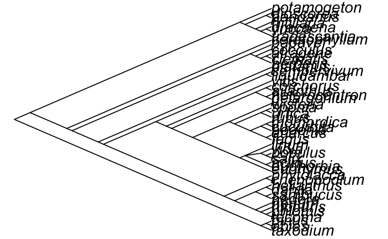

```r
plot(tree_phylomatic_EG1, no.margin = TRUE, type="cladogram")
```

```r
newick_fn4 = "tree_phylomatic_EG1"
write.tree(tree_phylomatic_EG1, file=newick_fn4)
#repeating to get tree from Zanne2014
tree_phylomatic_EG2 <- phylomatic(taxa = EG, storedtree ="zanne2014", get = 'POST')
```

```
NOTE: 30 taxa not matched: pinaceae/abies/abies, NA/aspicllum/aspicllum, NA/bangia/bangia, NA/blasia/blasia, NA/blechnum/blechnum, NA/caulerpa/caulerpa, ceratophyllaceae/ceratophyllum/ceratophyllum, NA/corallorrhiza/corallorrhiza, NA/equisetum/equisetum, NA/fontinalis/fontinalis, NA/fossombronia/fos…
```

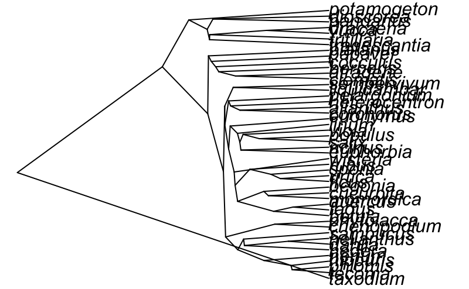

```r
plot(tree_phylomatic_EG2, no.margin = TRUE, type="cladogram")
```

```r
newick_fn5 = "tree_phylomatic_EG2"
write.tree(tree_phylomatic_EG2, file=newick_fn5)
```

#### MINI-EXERCISE 5

Do and write up notes about two things:

1. Try generating these trees again, but change from cladogram to phylogram, or to another format for the tree.

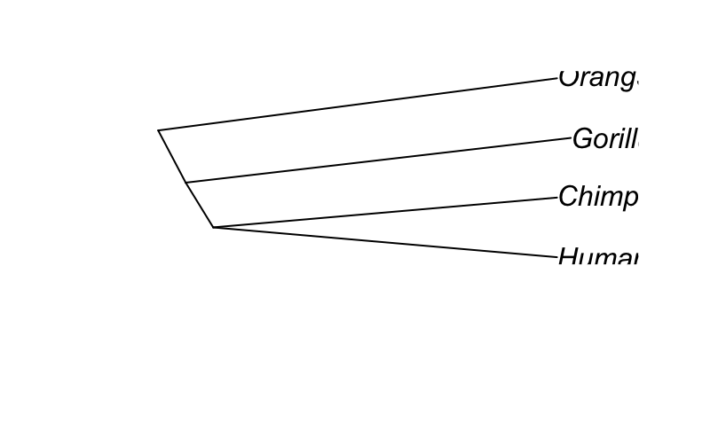

```r
plot(tr_primate, type="cladogram")
```

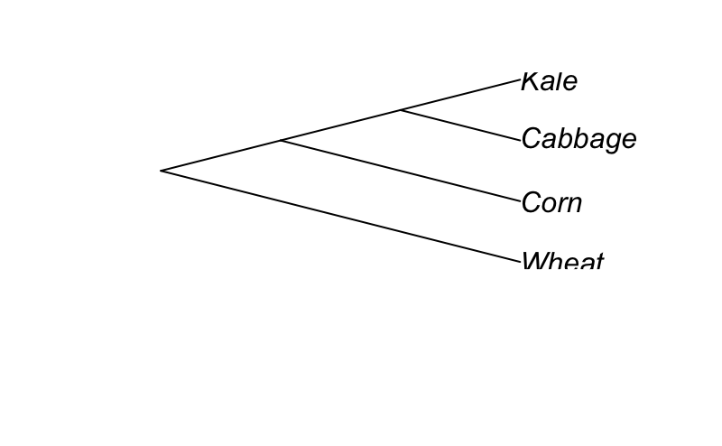

```r
plot(tr2_plants, type="cladogram")
```

2. Then, looking at all your output, what differs most noticably between the pair of trees, and how/why does this relate to the storedtree used to generate them? Try to explain what this means in your own words.
3. Lastly, look at the output and you’ll see that many taxa were excluded. Try looking them up in EOL or Wikipedia. Why was it difficult to include them? What does this say about the history of botany? Are there some things that were excluded that should not have been excluded.

# FINISHING UP - MICRO-EXERCISES AND A MACRO-EXERCISE

To finish up all the homework and work from today, you need to work through all the mini-exercises CORRECTLY. As appropriate, after our Digital Lab 3 session on 3/5, take time to go back and complete them (and add your commentary).

Next, you prepared lists for Portfolio 2. You can use these to finish up this workbook, as long as you have at least two lists of 25 taxa each.

Format the list so that you can enter it into the phyomatic commands above – probably by cutting and pasting a list of taxa. You may need to insert quotation marks and/or commas. I encourage you to try a diffrent way of doing this: prepare a file, save it as a *.txt file and then read it and use the file.

Your list/file can then be used to obtain a phylogenetic tree using the code learned above for Phylomatic.

Plot your tree in one or more formats (e.g., fan, phylogeny, cladogram). Save that in pdf format.

YOu were able to make those plots because phylomatic generated Newick trees, which you you need to save, too. Use *.txt format.

You can then use those output files to begin the part of the Portfolio that uses Interactive Tree of Life.

Lastly, be sure to save your R Notebook with appropriate output and commentary.

When your finished with this part of Portfolio 3, you can and should push the notebook and associated exported files back to the appropriate GitHub Repository for Digital Lab 3.